# LAB 4 - PARTE 2

Anne Gabriele Arcanjo

7/4/2019

# Sobre os dados a serem descritos

Fonte dos dados: - IDH Mundial http://hdr.undp.org/en/composite/HDI (2017) - Indice de Liberdade https://www.heritage.org/index/excel/2019/index2019_data.xls (2019)

# Captura dos dados

# Ajuste dos Dads

# Visualizações - RANK DE LIBERADE

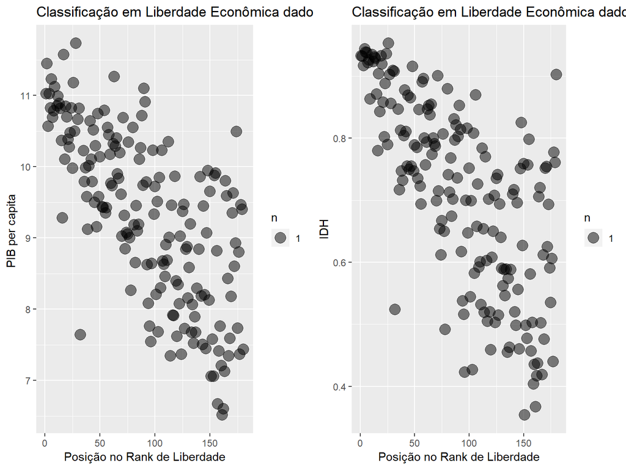

# Business Freedom

#### Liberdade para Empreender

É um indicador geral da eficiência da regulamentação governamental de negócios. A pontuação quantitativa é derivada de uma matriz de medidas da dificuldade de iniciar, operar e fechar um negócio. A pontuação de liberdade de negócios para cada país é um número entre 0 e 100, com 100 igualando-se ao ambiente de negócios mais livre. A pontuação é baseada em 10 fatores, todos ponderados de forma igual, usando dados do estudo Doing Business do Banco Mundial:

- Iniciar um negócio - procedimentos (número);
- Começar um negócio - tempo (dias);
- Iniciando um negócio - custo (% da renda per capita);
- iniciar um negócio - capital mínimo (% da renda per capita);
- Obtenção de uma licença - procedimentos (número); 1
- Obtenção de uma licença - tempo (dias);
- Obtenção de uma licença - custo (% da renda per capita);
- Fechando um negócio - tempo (anos);
- Fechamento de um negócio - custo (% da renda); e
- Fechamento de um negócio - taxa de recuperação (centavos por dólar) .2

Para mais detalhes sobre a formulação dos dados: https://www.heritage.org/index/business-freedom

# Visualizações - LIBERDADE PARA EMPREENDER

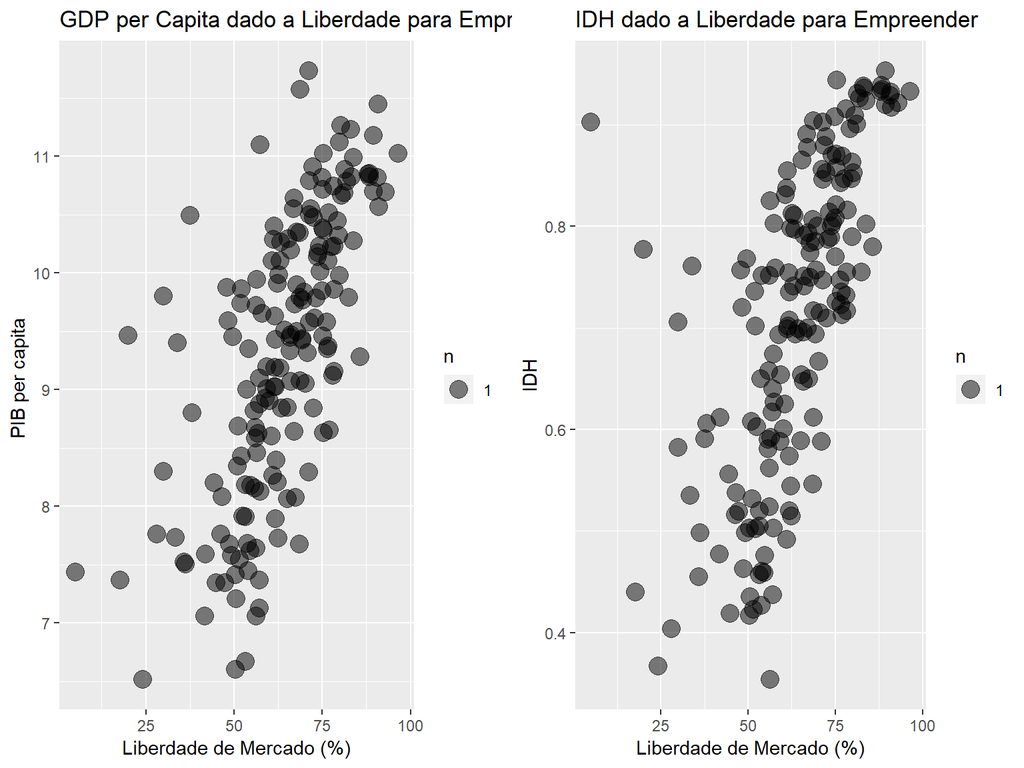

# Labor Freedom

#### Liberdade de Trabalho

O componente de liberdade trabalhista é uma medida quantitativa que considera vários aspectos do arcabouço legal e regulatório do mercado de trabalho de um país, incluindo regulamentações relativas a salários mínimos, leis que inibem demissões, exigências de demissão e restrições normativas mensuráveis na contratação e horas trabalhadas.

Seis fatores quantitativos são igualmente ponderados, cada um contado como um sexto do componente de liberdade de trabalho:

- Rácio do salário mínimo para o valor acrescentado médio por trabalhador,
- impedimento de contratar trabalhadores adicionais,
- rigidez de horas,
- Dificuldade de demitir funcionários redundantes,
- Período de notificação legalmente obrigatório e
- indenização compulsória.

Para mais detalhes sobre a formulação dos dados: https://www.heritage.org/index/labor-freedom

# Visualizações - LIBERDADE DE TRABALHO

### GDP per Capita e IDH dado a Liberdade de Trabalho

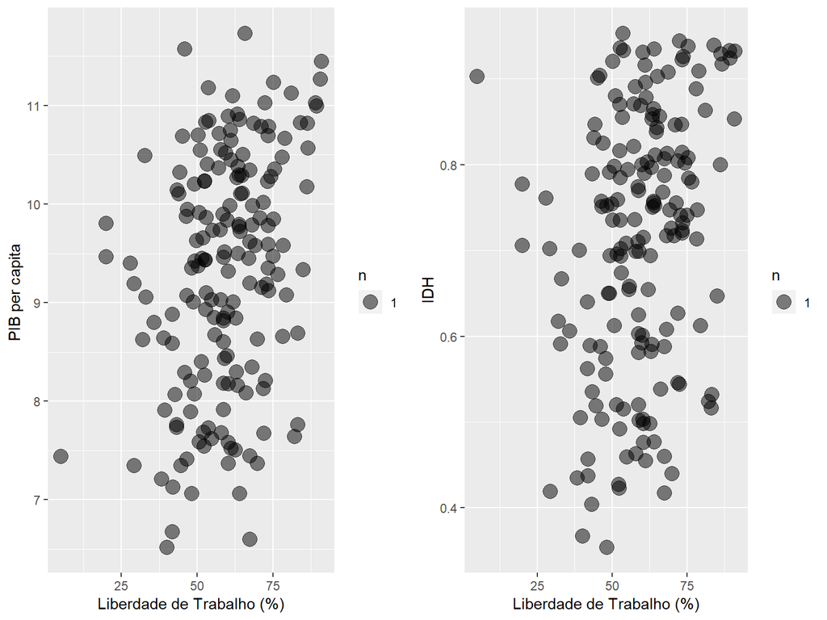

# Monetary Freedom

#### Liberdade de Monetária

A liberdade monetária combina uma medida de estabilidade de preços com uma avaliação dos controles de preços. Tanto a inflação quanto os controles de preços distorcem a atividade do mercado. Estabilidade de preços sem intervenção microeconômica é o estado ideal para o livre mercado.

A pontuação para o componente liberdade monetária é baseada em dois fatores:

- A taxa de inflação média ponderada para os três anos mais recentes e
- Controles de preço.

Para mais detalhes sobre a formulação dos dados: https://www.heritage.org/index/monetary-freedom

# Visualizações - LIBERDADE MONETÁRIA

### GDP per Capita e IDH dado a Liberdade Monetária

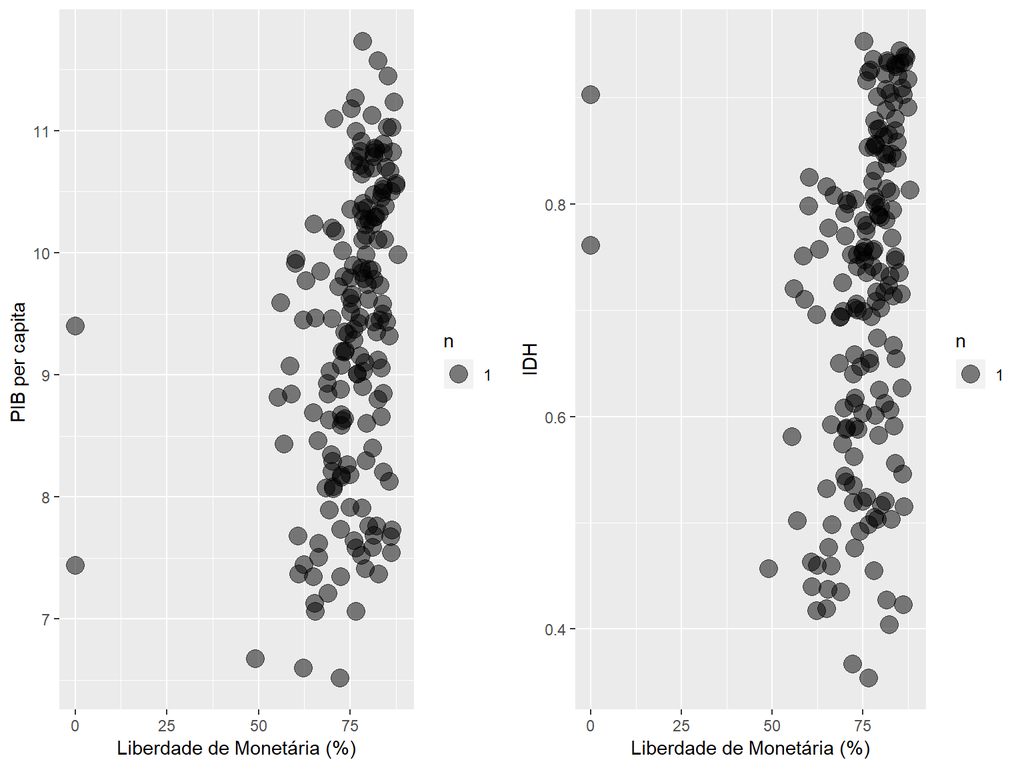

# Visualizações - EXPECTATIVA MÉDIA DE ANOS DE ESTUDO

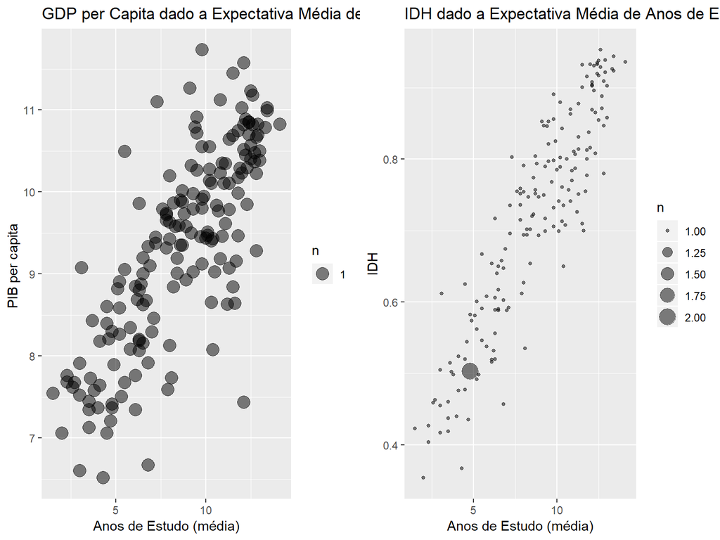